# Models

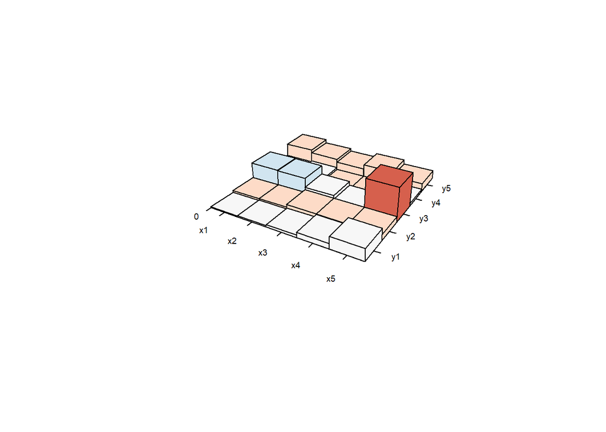

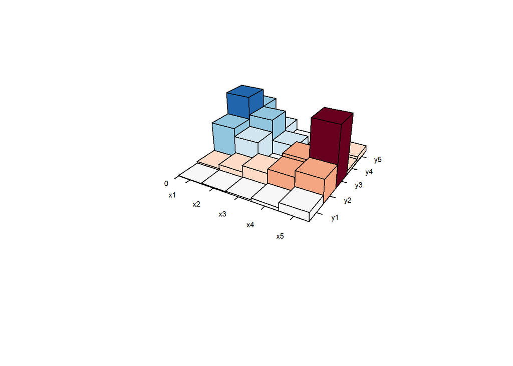

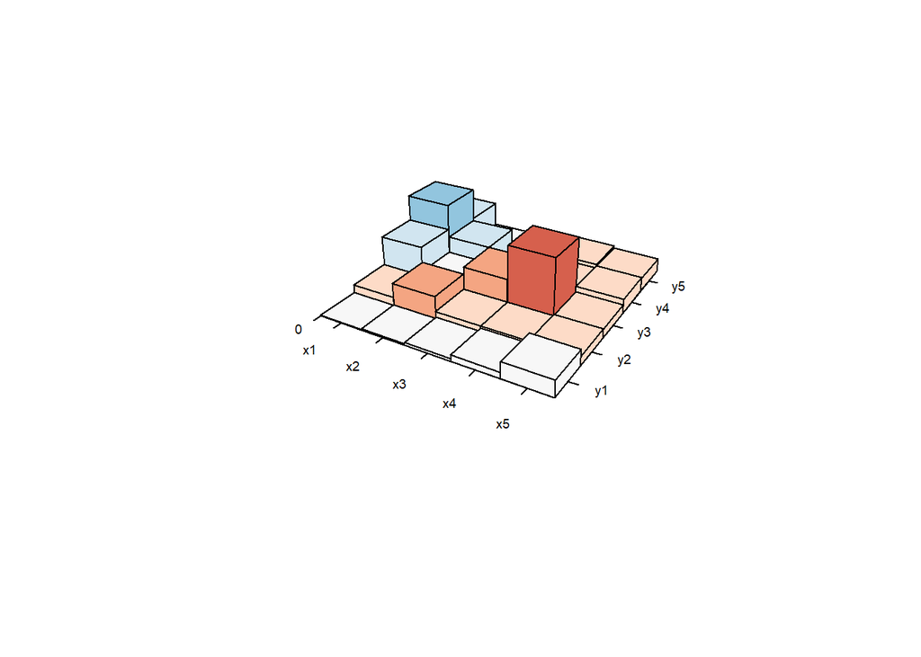

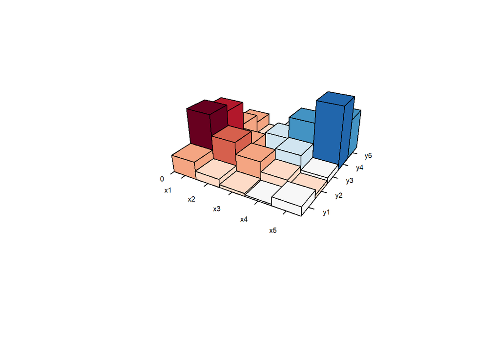

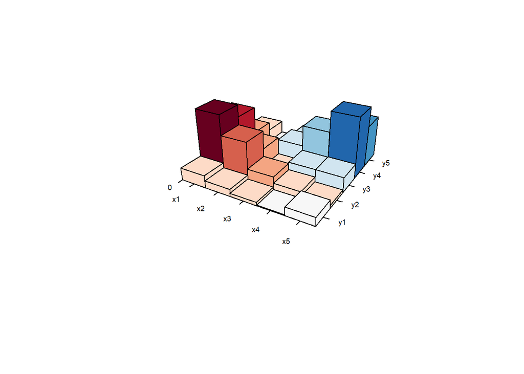

From the plots, we can tell that the TCoG-only model struggles the most with the *smallest falls* from the highest pitch accent step (cells 5-2, 5-3). This makes sense, especially since 5-3 is among the steps closest to a plateau. It also struggles with cell 1-4, which is the second-steepest rise. But, when we add in the global pattern parameter, the issues with the falling cells are eliminated almost entirely. Now, cell 4-3 (also plateau-like) is the issue. The magnitude of the differential for cell 1-4 decreases noticeably as well.

For the slope model on the other hand, it struggles with a different set of cells entirely (and the magnitudes of the worst offenders are higher than that of the TCoG model’s). Moreover, adding the global pattern parameter doesn’t really help it. There’s a sall reduction in cell 5-4, but column 1 is essentially unchanged.

### Exp2 -> Exp2

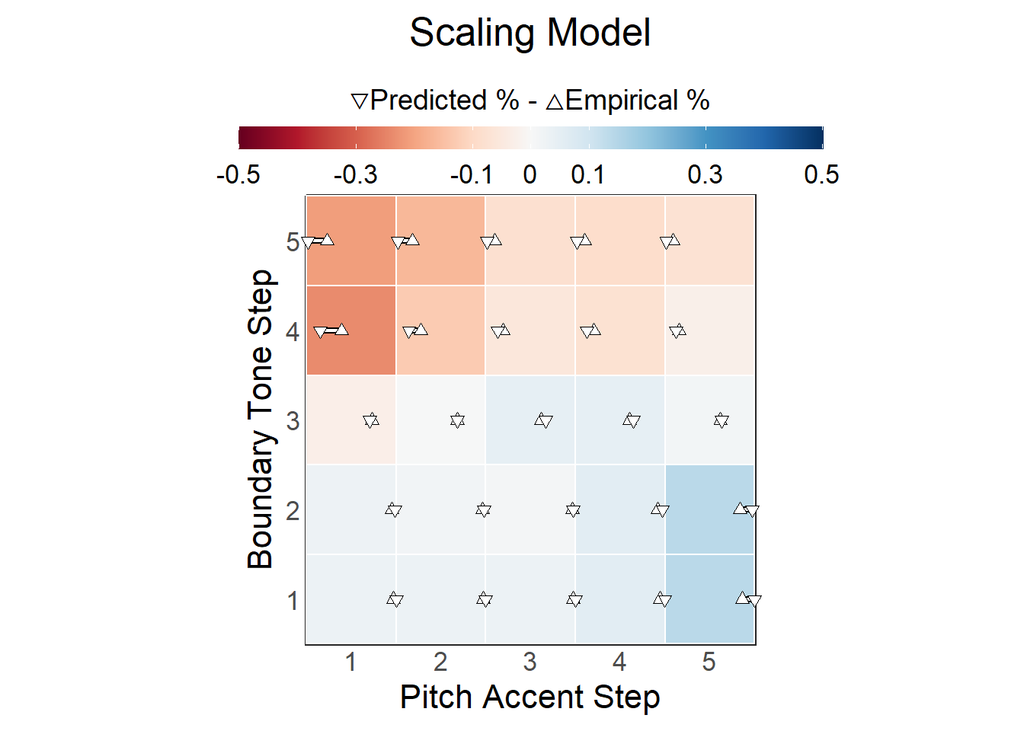

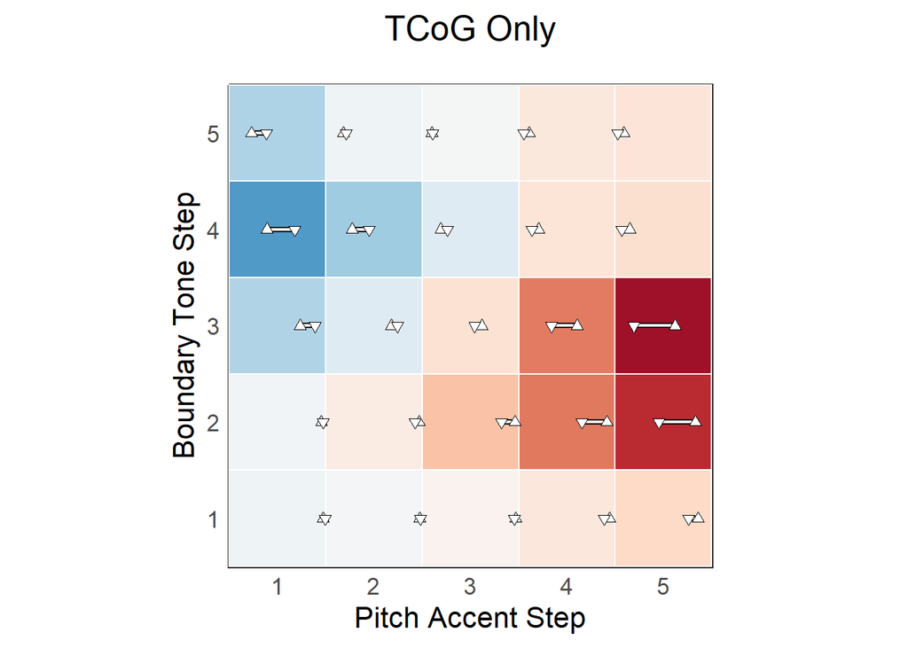

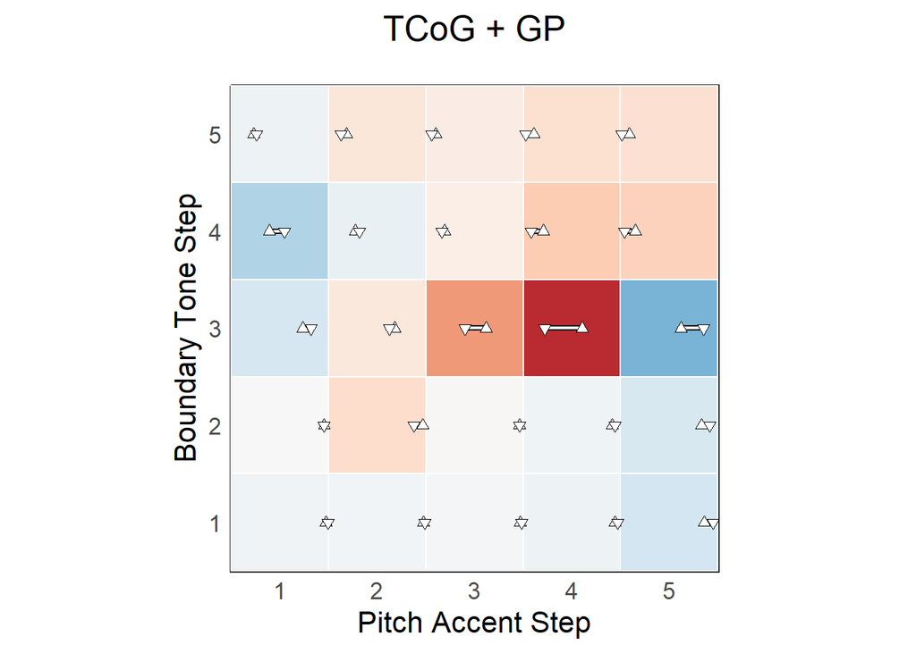

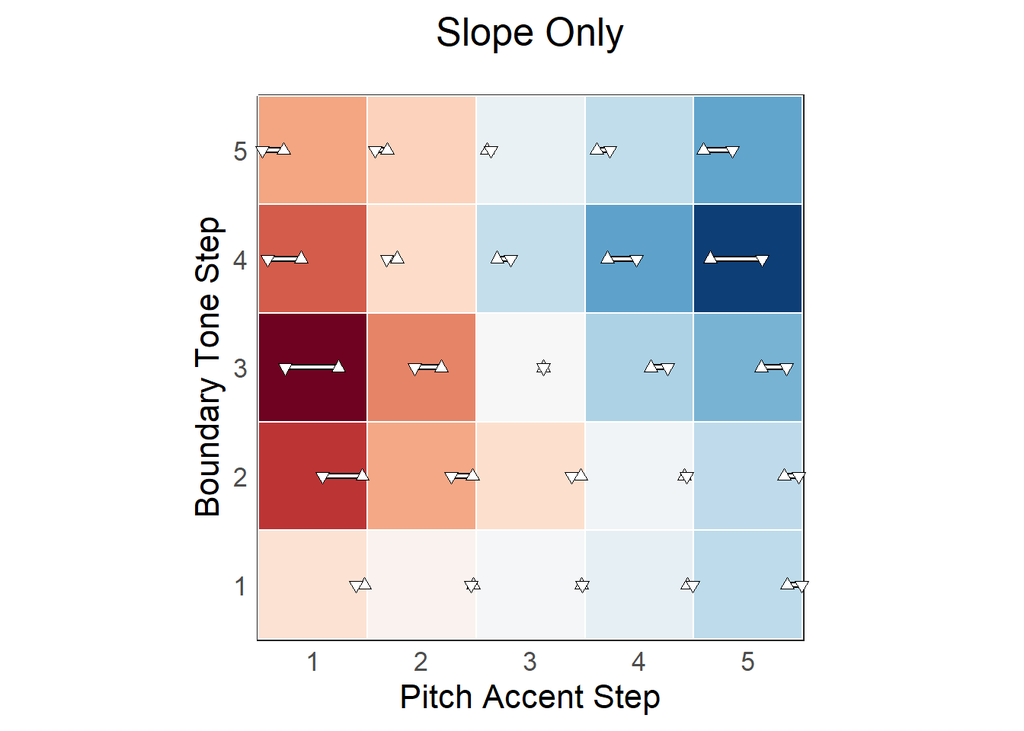

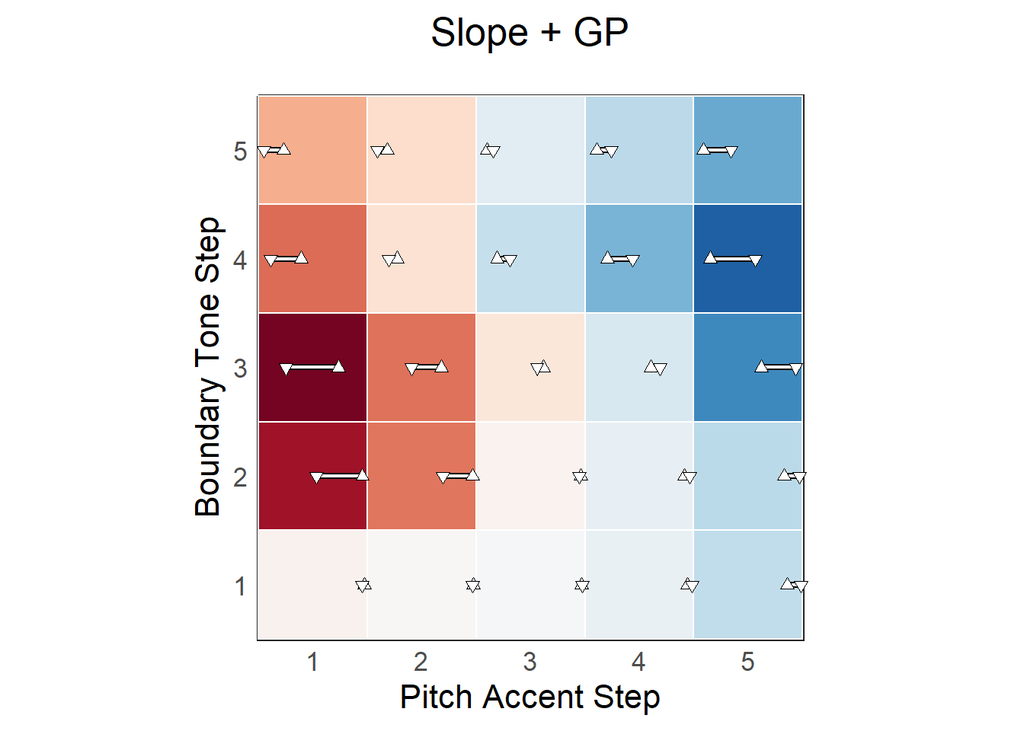

We can see that for the TCoG and slope models, the patterns from the previous section remain. The same offenders are immediately apparent, but the magnitudes relative to the previous model are reduced.

# Model Comparison: AUC

Next we’ll plot the ROC curves from the model of one experiment fit to the dataset of the other experiment. For example, take the tcog-only model from experiment 1 and predict the dataset in experiment 2. If, for example, TCoG is more explanatory than slope is, then this would carry over to the TCoG values of experiment 2, but the slope model would underperform. In each of these sets of plots, the top row is predicting Experiment 2 from Experiment 1, then the opposite in the second row.

## TCoG-only versus Slope-Only

Below we plot our two most parsimonious models using only TCoG or slope. *TCoG-only* on the left, *Slope only* on the right. Higher AUC values indicates better classification performance. We know slope is going to do a decent job, but does TCoG do any better?

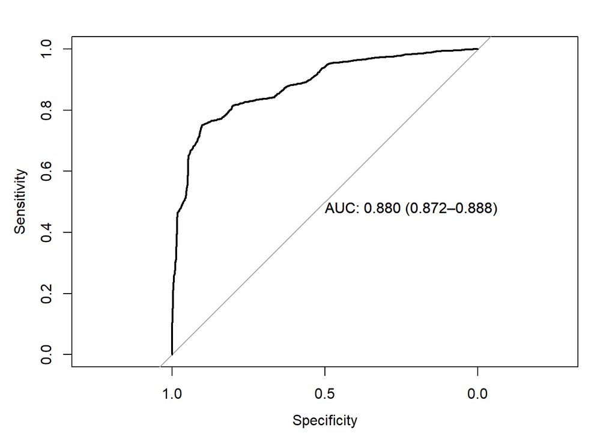

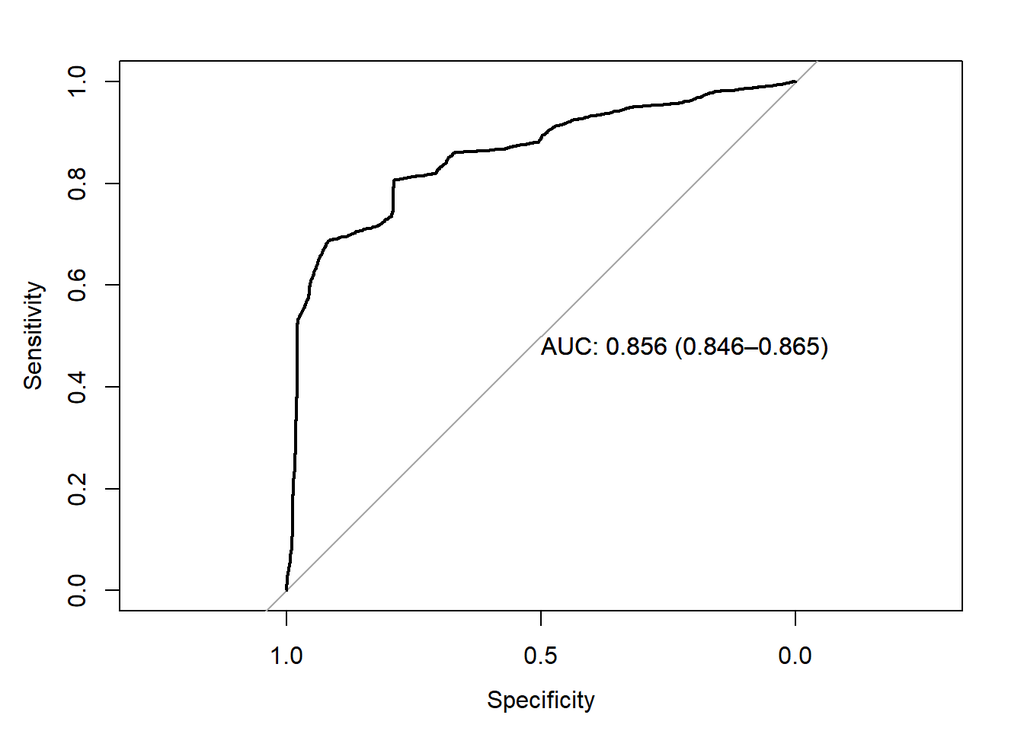

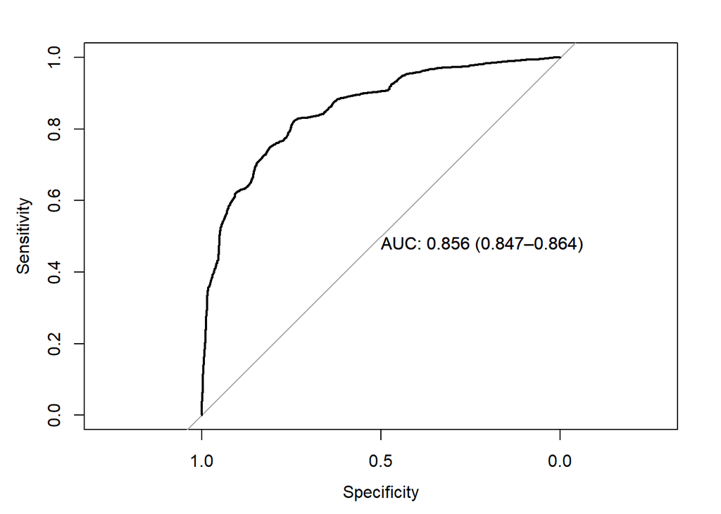

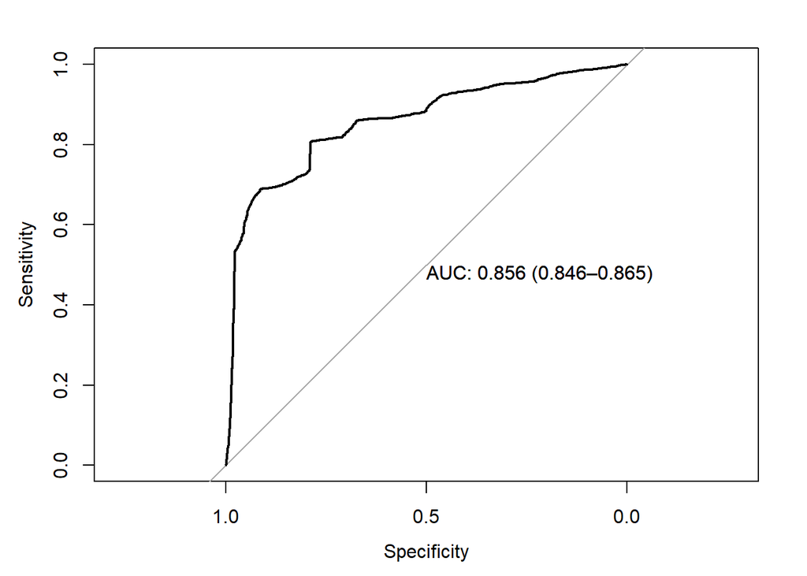

```r
exp1_tcogonly_roc <- roc_curve(exp1_tcogonly_reg, exp2_data)
# AUC: .8801 <-- better than slope

exp1_slopeonly_roc <- roc_curve(exp1_slopeonly_reg, exp2_data)
# AUC: 0.856

exp2_tcogonly_roc <- roc_curve(exp2_tcogonly_reg, exp1_data)
# AUC: 0.856 <-- better than slope

exp2_slopeonly_roc <- roc_curve(exp2_slopeonly_reg, exp2_data)
# AUC: 0.815
```

And here are all the AUC values in a table:

| TrainModel | TestData | AUC | Error |
| --- | --- | --- | --- |
| exp1_tcogonly_reg | exp2_data | 0.880 | 0.0041 |
| exp1_slopeonly_reg | exp2_data | 0.856 | 0.0046 |
| exp2_tcogonly_reg | exp1_data | 0.856 | 0.0044 |
| exp2_slopeonly_reg | exp2_data | 0.856 | 0.0046 |

## TCoG-only versus Scaling

Now let’s take our TCoG-only model and compare it to the scaling model. A priori we would expect the scaling model to do better since it has more parameters to work with.

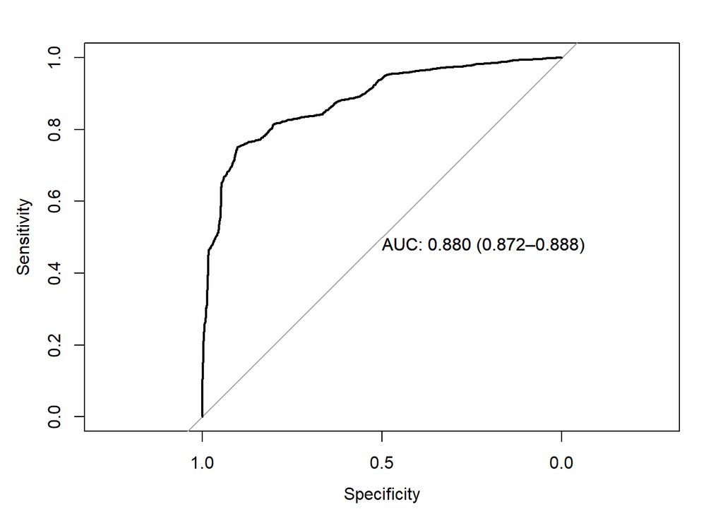

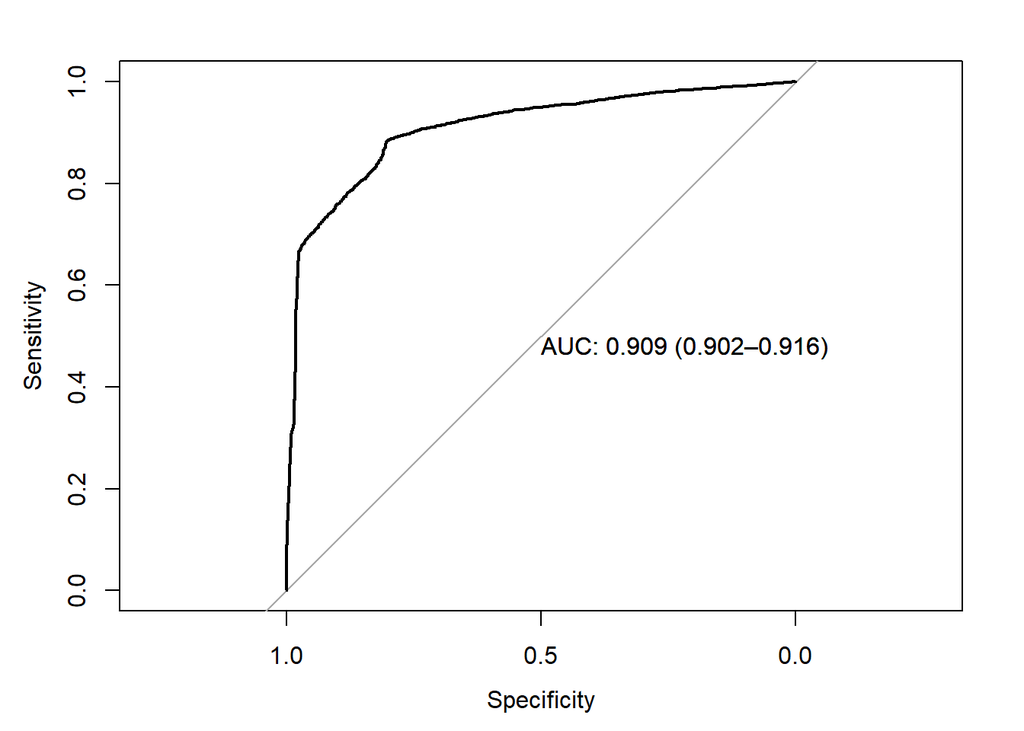

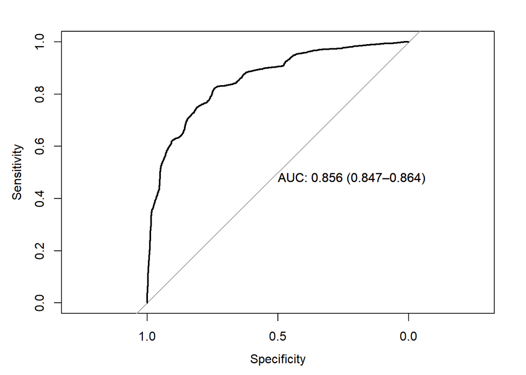

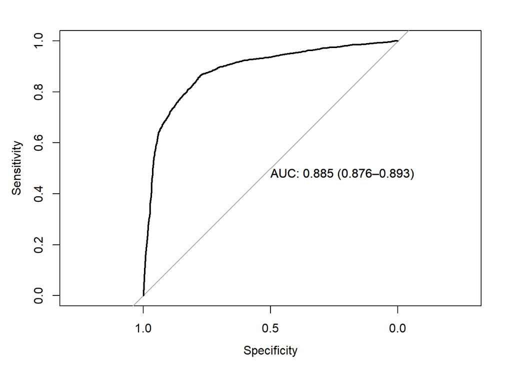

| TrainModel | TestData | AUC | Error |
| --- | --- | --- | --- |
| exp1_tcogonly_reg | exp2_data | 0.880 | 0.0041 |
| exp1_scaling_reg | exp2_data | 0.909 | 0.0036 |
| exp2_tcogonly_reg | exp1_data | 0.856 | 0.0044 |
| exp2_scaling_reg | exp1_data | 0.885 | 0.0040 |

```r
plot(exp1_tcogonly_roc, print.auc = TRUE)
exp1_scaling_roc <- roc_curve(exp1_scaling_reg, exp2_data)
# AUC: 0.910 <-- better than tcog alone

plot(exp2_tcogonly_roc, print.auc = TRUE)
exp2_scaling_roc <- roc_curve(exp2_scaling_reg, exp1_data)
# AUC: 0.885 <-- better than tcog alone
```

Unsurprisingly, the scaling model has higher AUC values. So far, the scaling model beats the TCoG-only and slope-only models

## TCoG+Global Pattern versus Scaling

Finally, we test the TCoG model when augmented with “top-down” information about whether the global pattern[^2] is rising or falling. This is implemented as a simple 2-level categorical variable encoding the global rise/fall, along with an interaction with TCoG. This gives the model the same number of parameters as the scaling model, which makes them a bit more comparable.

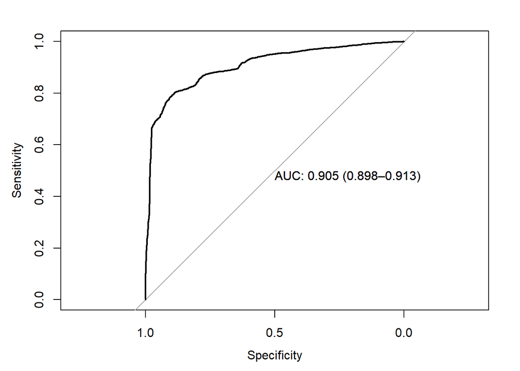

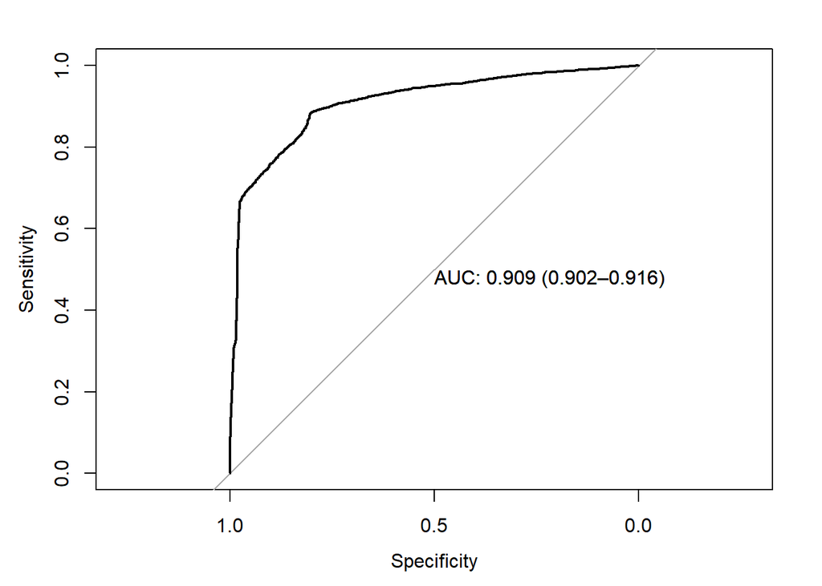

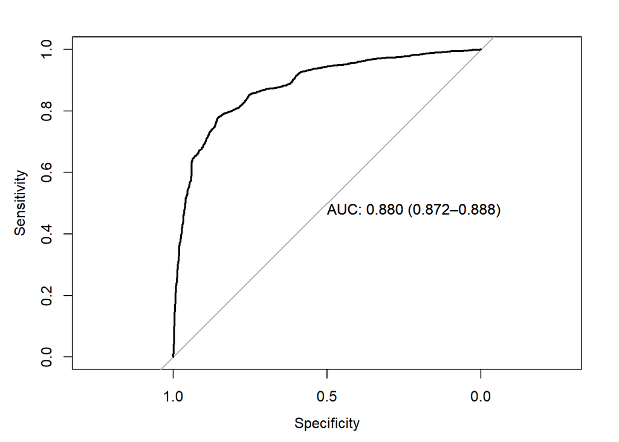

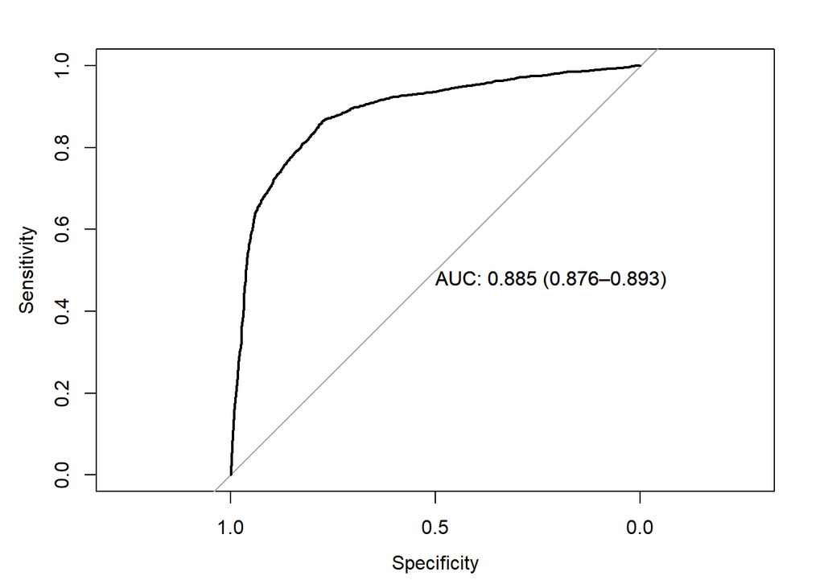

| TrainModel | TestData | AUC | Error |
| --- | --- | --- | --- |
| exp1_tcogonly_reg | exp2_data | 0.880 | 0.0041 |
| exp1_tcog_reg | exp2_data | 0.905 | 0.0037 |
| exp1_scaling_reg | exp2_data | 0.909 | 0.0036 |
| exp2_tcogonly_reg | exp1_data | 0.856 | 0.0044 |
| exp2_tcog_reg | exp1_data | 0.880 | 0.0040 |
| exp2_scaling_reg | exp1_data | 0.885 | 0.0040 |

```r
exp1_tcog_roc <- roc_curve(exp1_tcog_reg, exp2_data)
# AUC: .8801 <-- better than slope

plot(exp1_scaling_roc, print.auc = TRUE)
exp2_tcog_roc <- roc_curve(exp2_tcog_reg, exp1_data)
# AUC: .8801 <-- better than slope

plot(exp2_scaling_roc, print.auc = TRUE)
```

Based just on the numbers, the scaling model ekes out a miniscule amount of additional classification performance compared to the augmented TCoG model. The magnitude is much smaller than the model comparisons we previously looked at. Before, the differences were on the scale of about 2-5%, but here the difference is barely .5%. So, even though the scaling model may be numerically a tiny bit better, it is much more difficult to interpret (remember the Exp1 model showed a counterintuitive *negative* effect). The augmented TCoG model is much more straightforward to interpret. Honestly, even without the augmentation it’s still just as easy to interpret (and more parsimonious and bottom-up).

## TCoG+GP versus Slope+GP

In the previous section we saw how augmenting the TCoG model put its performance at nearly the same level as the scaling model. But this raises the question of whether the slope model actually *is* the proper way to characterize the data, but it also just needs to be similarly augmented. Here, I compare the TCoG+GP model with a Slope+GP model

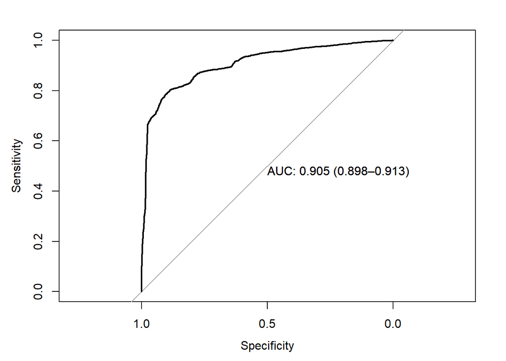

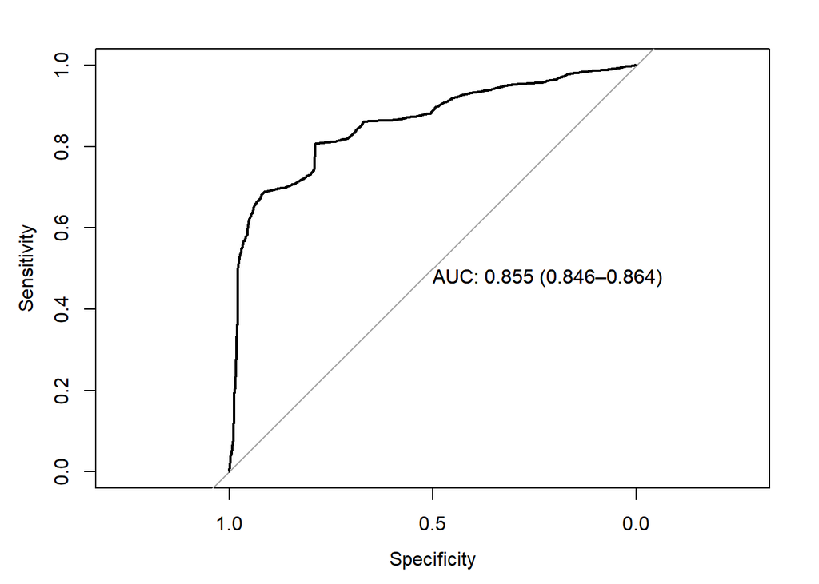

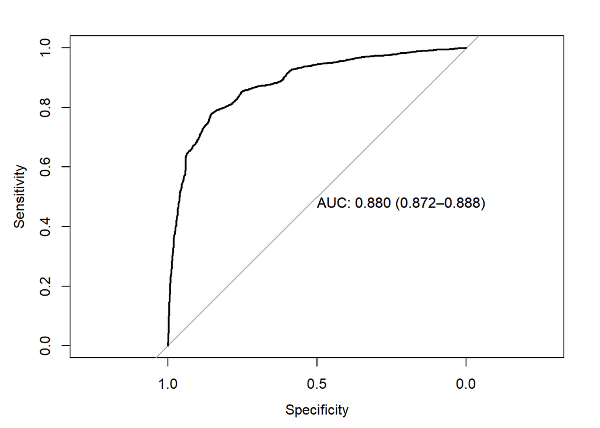

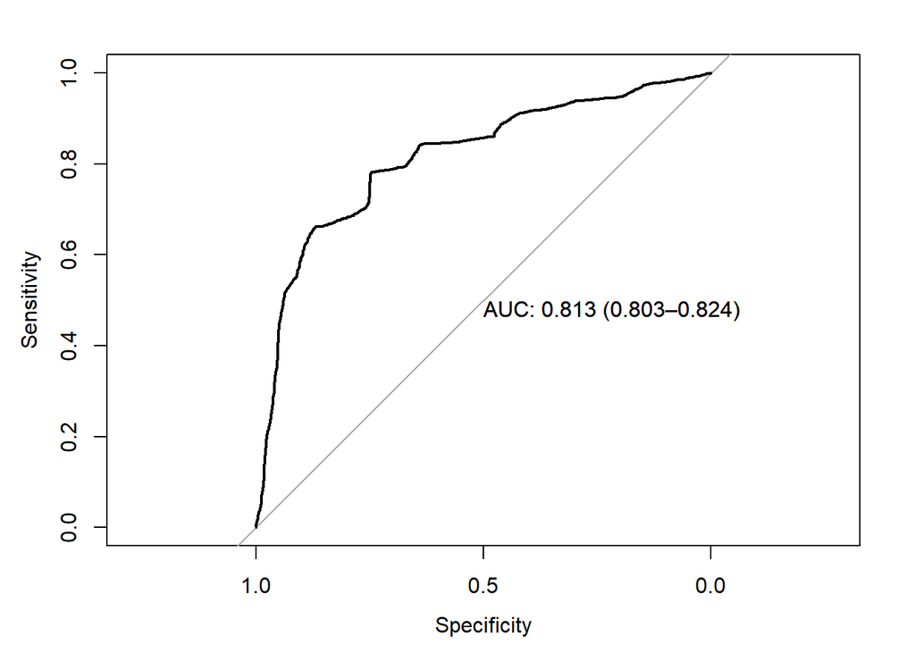

| TrainModel | TestData | AUC | Error |
| --- | --- | --- | --- |
| exp1_tcogonly_reg | exp2_data | 0.880 | 0.0041 |
| exp1_tcog_reg | exp2_data | 0.905 | 0.0037 |
| exp1_slopeonly_reg | exp2_data | 0.856 | 0.0046 |
| exp1_slope_reg | exp2_data | 0.855 | 0.0046 |
| exp2_tcogonly_reg | exp1_data | 0.856 | 0.0044 |
| exp2_tcog_reg | exp1_data | 0.880 | 0.0040 |
| exp2_slopeonly_reg | exp2_data | 0.856 | 0.0046 |
| exp2_slope_reg | exp1_data | 0.813 | 0.0051 |

```r
plot(exp1_tcog_roc, print.auc = TRUE)
exp1_slope_roc <- roc_curve(exp1_slope_reg, exp2_data)
# AUC: .8801 <-- better than slope

plot(exp2_tcog_roc, print.auc = TRUE)
exp2_slope_roc <- roc_curve(exp2_slope_reg, exp1_data)
# AUC: .8801 <-- better than slope
```

Based on this last set of comparisons, we can see that augmenting the slope model doesn’t help nearly as much as augmenting the TCoG model did. In fact, looking at the values in the table, augmenting the slope model doesn’t help *at all*. The difference between the two models is 5-7%, which is quite large compared to previous comparisons.

## Conclusions

To really summarize the comparisons I’ve shown above, here is a plot of the AUC values with 95% confidence intervals for each model. The results are separated by which experiment is used for the training/test set, and shadows depicting all data points are used to compare across the dataset. I’ve also plotted all the ROC curves together into one panel below it.

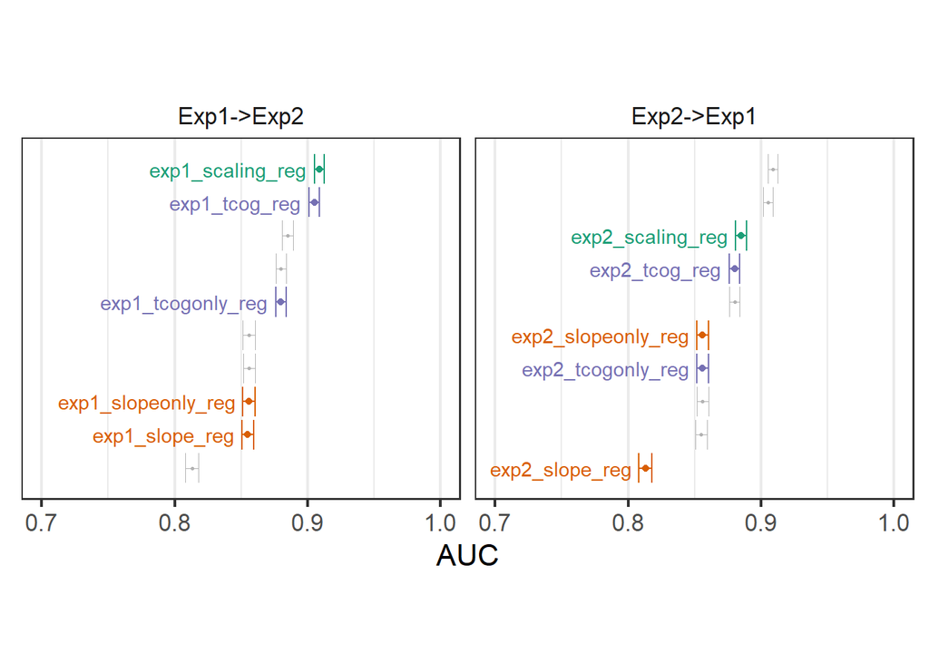

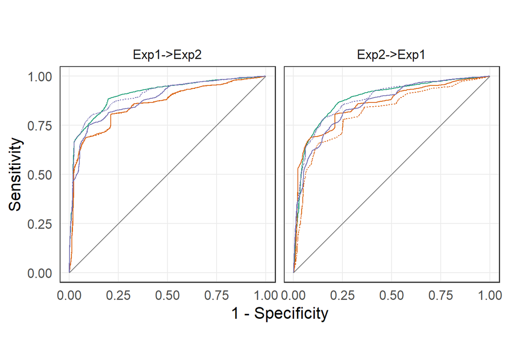

From these model comparisons we conclude that the TCoG model is superior to the slope model, whether it is augmented or not. Moreover, an augmented TCoG model is preferable to the scaling model on the basis of its relation to linguistic theory (avoiding the counterintuitive pitch accent effect altogether).

## Footnotes

[^1]: In the plots, the predicted and empirical proportions are plotted *within each cell* such that 0% corresponds to the left edge of the cell and 100% corresponds to the right edge of the cell. Thus, the difference in proportions is encoded by both the color of the cell and the length of the bar between the two triangles.
[^2]: I’ll use GP to stand for global pattern